## Statistics Course Project : Part 1

### Nima Alizadeh

#### 98100504

### Problem 1

### a

Distribution selected for this problem is exponential distribution.

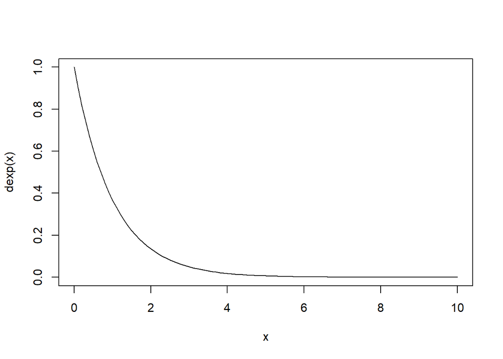

   ```r
   curve(dexp,from=0,to=10)
   ```

2. Variable `data_rate` is the parameter of exponential distribution. Generating first set of samples:

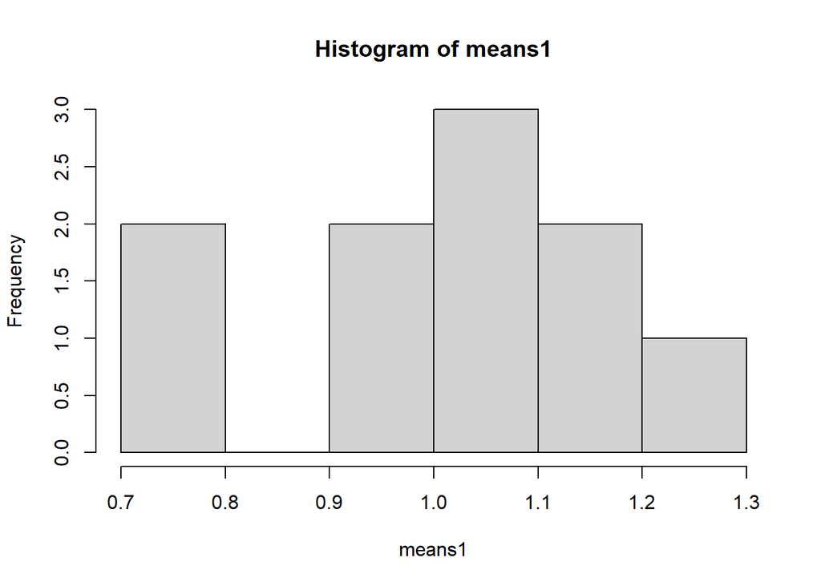

   ```r
   data_rate=1
   data1=rexp(500,rate=data_rate)
   matrix1 <- matrix(data1,nrow=50,ncol=10)
   means1=apply(matrix1,2,mean)
   hist(means1)
   ```

   Generating second set of samples:

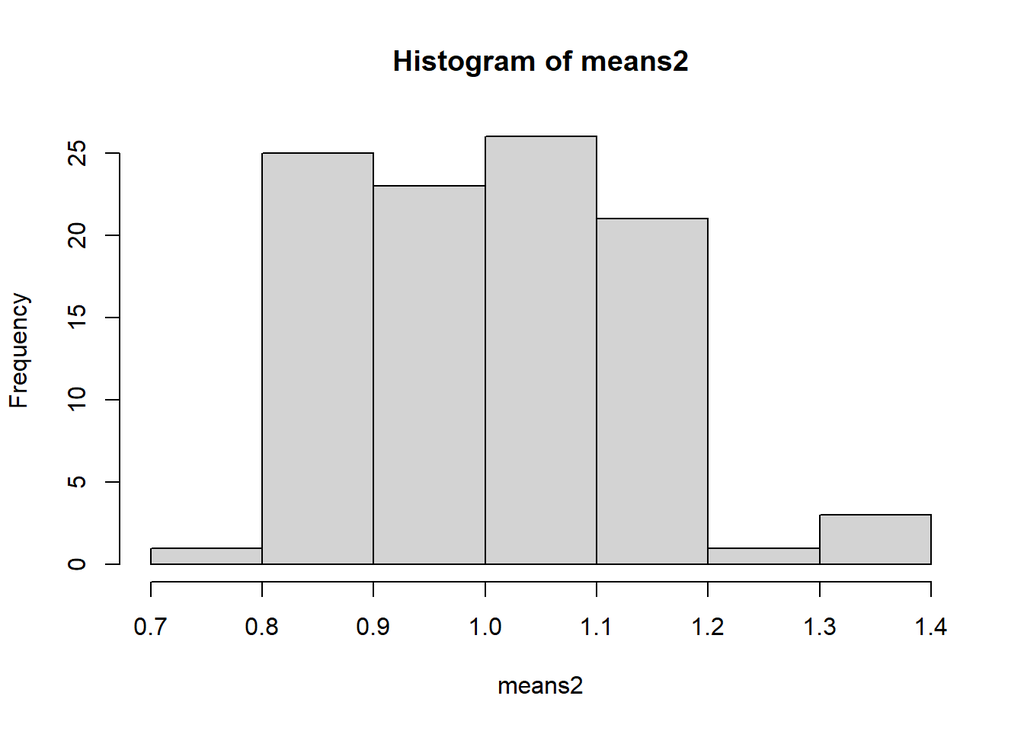

   ```r
   data2=rexp(5000,rate=data_rate)
   matrix2 <- matrix(data2,nrow=50,ncol=100)
   means2=apply(matrix2,2,mean)
   hist(means2)
   ```

   Generating third set of samples:

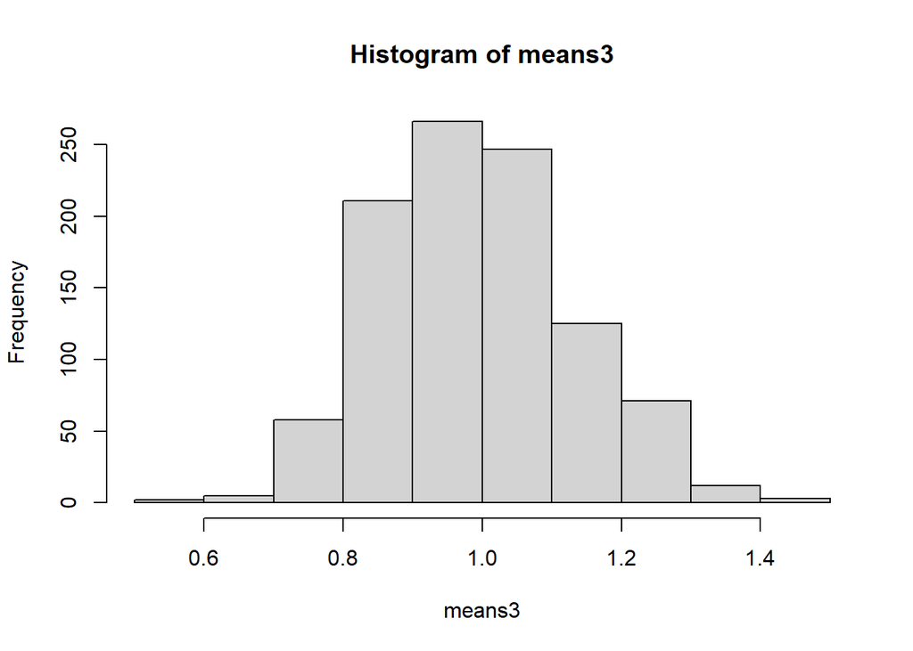

   ```r
   data3=rexp(50000,rate=data_rate)
   matrix3 <- matrix(data3,nrow=50,ncol=1000)
   means3=apply(matrix3,2,mean)
   hist(means3)
   ```

3. Computing mean and variance of means in each sample set:

   ```r
   means=c(mean(means1),mean(means2),mean(means3))
   print(paste("means are:",means))
   ```

   ```
   ## [1] "means are: 1.01007390876312"  "means are: 1.00711476014338"
   ## [3] "means are: 0.992456784235558"
   ```

   ```r
   vars=c(var(means1),var(means2),var(means3))
   print(paste("variance of means  are:",vars))
   ```

   ```
   ## [1] "variance of means  are: 0.0299415692546349"
   ## [2] "variance of means  are: 0.0163280649321062"
   ## [3] "variance of means  are: 0.0188804175633061"
   ```

   Normalizing means for each sample set and comparing them with normal distribution. First set:

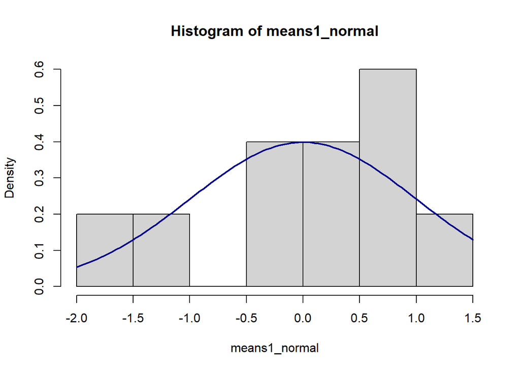

   ```r
   means1_normal=(means1-means[1])/(sqrt(vars[1]))
   hist(means1_normal, freq=FALSE)
   curve(dnorm, col="darkblue", lwd=2, add=TRUE, yaxt="n")
   ```

   Second set:

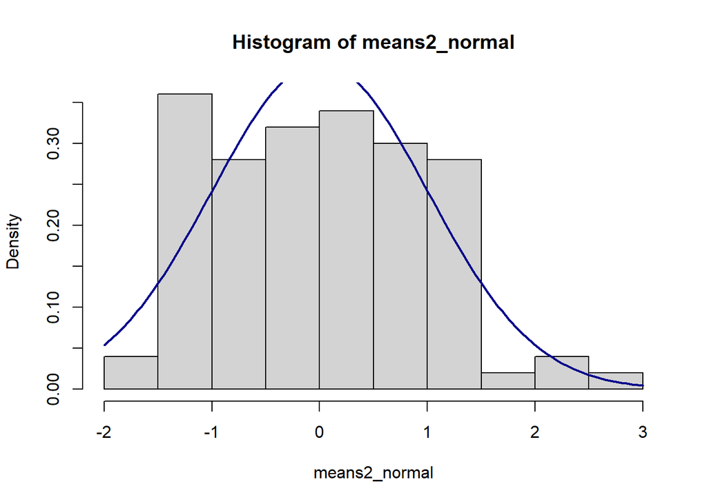

   ```r
   means2_normal=(means2-means[2])/(sqrt(vars[2]))
   hist(means2_normal,freq=FALSE)
   curve(dnorm, col="darkblue", lwd=2, add=TRUE, yaxt="n")
   ```

   Third set:

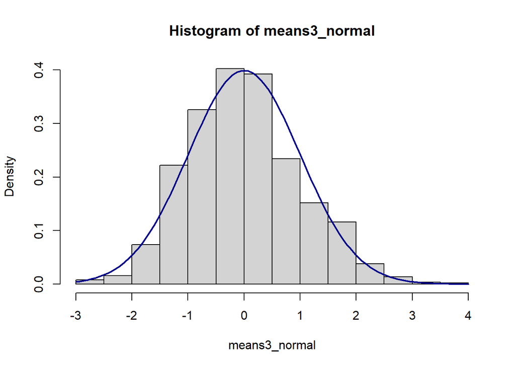

   ```r
   means3_normal=(means3-means[3])/(sqrt(vars[3]))
   hist(means3_normal,freq=FALSE)
   curve(dnorm, col="darkblue", lwd=2, add=TRUE, yaxt="n")
   ```

   As it can be seen in the figures, by increasing the number of samples, we get a distribution which is more similar the normal distribution. Central Limit theorem also confirms this fact, since by increasing the number of samples from a random variable, the distribution of the mean of the samples gets more close to normal.

### b

1. Importing dataset and computing the number of births in each day:

   ```r
   library(fastR2)
   daily_means=c(mean(Births$births[Births$day_of_year==1]))
   for(i in 2:365){
     daily_means=c(daily_means,mean(Births$births[Births$day_of_year==i]))
   }
   print(paste("maximum number of births happened in" ,which.max(daily_means),"th day of each year, in average"))
   ```

   ```
   ## [1] "maximum number of births happened in 260 th day of each year, in average"
   ```

   ```r
   print(paste("minimum number of births happened in" ,which.min(daily_means),"th day of each year, in average"))
   ```

   ```
   ## [1] "minimum number of births happened in 360 th day of each year, in average"
   ```

2. Computing average number of births in each month:

   ```r
   monthly_means=c(mean(Births$births[Births$month==1]))
   for(i in 2:12){
     monthly_means=c(monthly_means,mean(Births$births[Births$month==i]))
   }
   print(paste("Average number of births in each month ( from Jan to Dec) is "))
   ```

   ```
   ## [1] "Average number of births in each month ( from Jan to Dec) is "
   ```

   ```r
   monthly_means
   ```

   ```
   ##  [1]  9288.976  9491.301  9464.742  9267.958  9331.000  9597.618 10032.734
   ##  [8] 10177.039 10343.287  9766.729  9492.122  9523.187
   ```

   ```r
   rev(order(monthly_means))
   ```

   ```
   ##  [1]  9  8  7 10  6 12 11  2  3  5  1  4
   ```

3. Computing average number of births in each year:

   ```r
   yearly_means=c(mean(Births$births[Births$year==1969]))
   for(i in 1970:1988){
     yearly_means=c(yearly_means,mean(Births$births[Births$year==i]))
   }
   yearly_means
   ```

   ```
   ##  [1]  9859.118 10231.797  9761.847  8923.123  8618.274  8685.770  8639.359
   ##  [8]  8678.322  9128.899  9145.745  9588.321  9885.104  9960.219 10096.915
   ## [15]  9980.085 10036.970 10315.216 10303.238 10447.153 10693.404
   ```

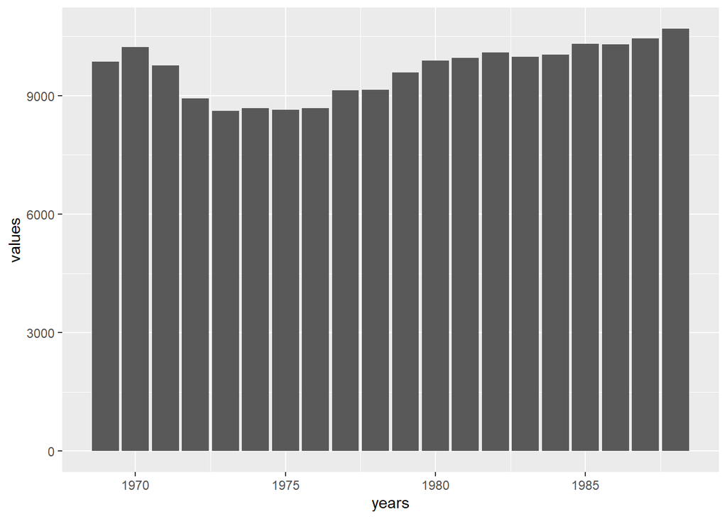

   ```r
   df_year <- data.frame(years=1969:1988,values=yearly_means)
   ggplot(data=df_year,aes(x=years,y=values))+geom_bar(stat = "identity")
   ```

### c

Importing dataset and loading required data from it:

```r
library(dplyr)
#View(storms[order(storms$),])
sorted_storms=storms[with(storms,order(storms$year,storms$month,storms$day,storms$hour)),]
write.table(sorted_storms,file="sorted storsm.RData") # saving sorted data
```

Plotting points:

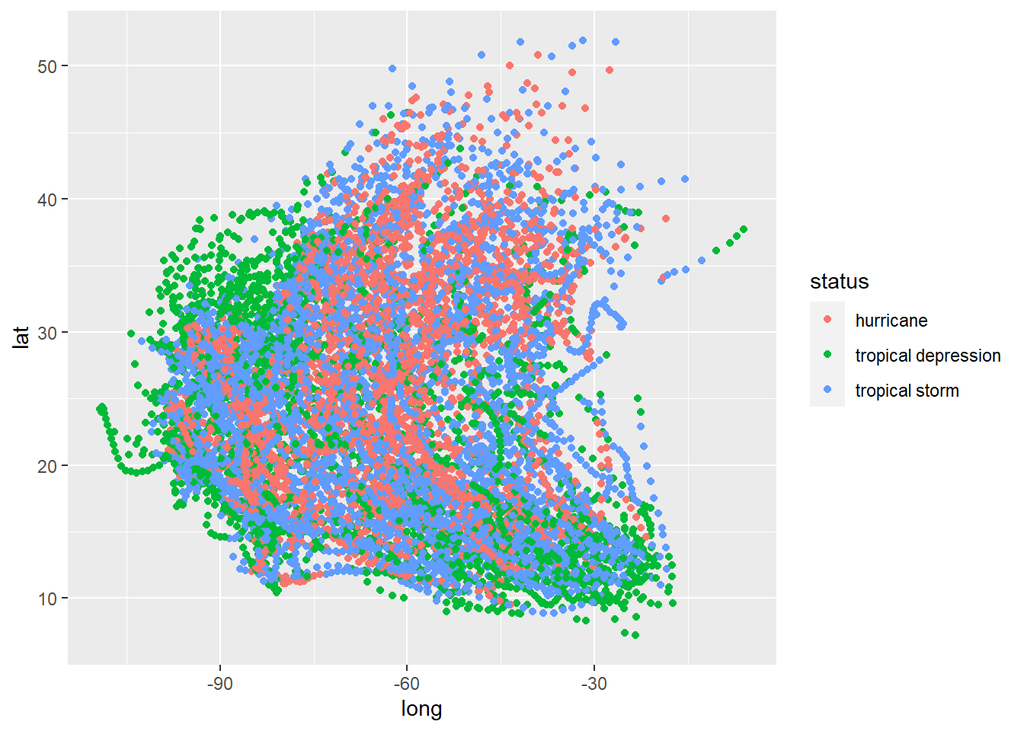

```r
# plotting points
#p=ggplot(data=sorted_storms)+geom_point(aes(long,lat))
#p
ggplot(data = sorted_storms)+geom_point(mapping = aes(x=long,y=lat, color=status))
```

### Problem 2

### a

Reading data from file:

```r
# reading data from file
heart_data=read.delim("had.txt",header=FALSE)
```

1. Seprating labels and features

   ```r
   # seprating labels and features
   label=heart_data[,7]
   features=heart_data[,1:6]
   ```

2. Dividing data to train and test parts

   ```r
   # dividing data to train and test parts
   train_indices=sample(nrow(heart_data),240)
   train_labels=label[train_indices]
   train_features=features[train_indices,]
   test_labels=label[-train_indices]
   test_features=features[-train_indices,]
   # saving tables
   write.table(train_labels,file="train labels.txt")
   write.table(train_features,file="train features.txt")
   write.table(test_labels,file="test labels.txt")
   write.table(test_features,file="test features.txt")
   ```

### b

1. Applying linear regression on training samples:

   ```
   ##
   ## Call:
   ## lm(formula = train_labels ~ V1 + V2 + V3 + V4 + V5 + V6, data = train_features)
   ##
   ## Residuals:
   ##     Min      1Q  Median      3Q     Max
   ## -2.1700 -0.5209 -0.1283  0.5795  1.8979
   ##
   ## Coefficients:
   ##               Estimate Std. Error t value Pr(>|t|)
   ## (Intercept)  1.9197489  0.5066025   3.789 0.000192 ***
   ## V1          -0.0130461  0.0060492  -2.157 0.032055 *
   ## V2          -0.5872479  0.1127098  -5.210 4.15e-07 ***
   ## V3           0.4637287  0.0512558   9.047  < 2e-16 ***
   ## V4          -0.0078235  0.0030540  -2.562 0.011047 *
   ## V5          -0.0005156  0.0010991  -0.469 0.639420
   ## V6          -0.0356276  0.1525503  -0.234 0.815542
   ## ---
   ## Signif. codes:  0 '***' 0.001 '**' 0.01 '*' 0.05 '.' 0.1 ' ' 1
   ##
   ## Residual standard error: 0.8083 on 233 degrees of freedom
   ## Multiple R-squared:  0.3613, Adjusted R-squared:  0.3449
   ## F-statistic: 21.97 on 6 and 233 DF,  p-value: < 2.2e-16
   ```

   In addition to regression coefficients, summary function also contains data about standard error, t-value , F-statistics, p-value and etc. as well. Standard error for each coefficient gives us a confidence interval for the actual regression coefficient, over the computed coefficient. T value for eahc coefficient is the ratio of the coefficient and standard error. Probability $\Pr\{>|t|\}$ gives the p-value, calculated from t-statistics of the coefficient, showing how significant the coefficient is. Residual standard error is the total error we have on our regression line.
2. Maximum and minimum coefficients are :

   ```r
   which.max(regression_data$coefficients)
   ```

   ```
   ## (Intercept)
   ##           1
   ```

   ```r
   which.min(regression_data$coefficients)
   ```

   ```
   ## V2
   ##  3
   ```

   This way of comparing coefficients is not correct, since features don’t have the same scale. To make this comparison meaningful, we should first normalize the features into the same scale, and then compute regression coefficients.

### c

First we define a function to apply regression coefficients on a given test dataset:

```r
apply_regression <- function(coeffs,test_data,dims){
  result=matrix(coeffs[1],nrow=dims[1],ncol=dims[2]+1)

  for(i in 1:dims[2]){
  result[,i+1]=coeffs[i+1]*test_features[,i]
  }

 result=rowSums(result)
}
```

We also define another function for estimating labels by a limit :

```r
estimate_labels <- function(result,limit,dim){
  labels=c(1:dim)
  labels[result>=limit]=1
  labels[result<limit]=-1
  return(labels)

}
```

Another function for computing the ratio of the correct labels in estimated labels :

```r
find_corrects_ratio <- function(est_labels,labels,dims){
  corrects=length(est_labels[est_labels==labels])
  ratio=corrects/dims
}
```

1. Applying regression on test dataset:

   ```r
   coeffs=regression_data$coefficients
   result=apply_regression(coeffs,test_features,c(63,6))
   estimates=estimate_labels(result,0,63)
   ratio=find_corrects_ratio(estimates,test_labels,63)
   print(paste("Ratio of correct estimates is:",ratio))
   ```

   ```
   ## [1] "Ratio of correct estimates is: 0.73015873015873"
   ```

2. We check the result of applying regression on test dataset for 50 different and uniform limits in [-2,2]

   ```r
   # computing ratios for 20 different limits in [-2,2]
   limits=seq(-2,2,length=50)
   ratios=c()
   for(i in limits){
     estimates=estimate_labels(result,i,63)
     ratio=find_corrects_ratio(estimates,test_labels,63)
     ratios=c(ratios,ratio)
   }
   print(paste("Maximum ratio is generated for limit ",limits[which.max(ratios)]))
   ```

   ```
   ## [1] "Maximum ratio is generated for limit  -0.204081632653061"
   ```

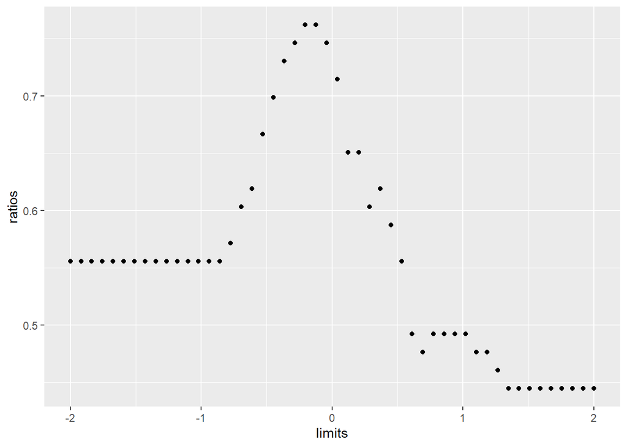

   ```r
   # plotting ratios and limits
   limits_ratios=data.frame(limits=limits,ratios=ratios)
   ggplot(data = limits_ratios)+geom_point(mapping = aes(x=limits,y=ratios))
   ```

### Problem 3

### a

Importin data from file:

```r
# reading data from excel file
library(readxl)
housing_data=read_excel('housing.xlsx',sheet="price of land")
```

[output not shown]

1. We find broken samples by considering NAs and strings and numbers smaller than 10:

   ```
   ## [1] "number of broken samples in each column is (from left to right)"
   ```

   ```r
   num_of_brokens
   ```

   ```
   ##  [1]  1  0  0  0  2  0  0  0  0  0  0  0  1  2  0  0  0  0  0  0  0  0  0  0  0
   ## [26]  0  0  0  0  0  0  0  0  0  0  1  1  4  4  6 13  9 19 18 19  8
   ```

2. We replace every element with a broken data in the table with a NA and remove all columns with at least 6 broken data :

   ```r
   # removing columns with at least one broken value
   brokens=which(num_of_brokens>=6)
   cleaned_data=cleaned_data[,-brokens]
   cleaned_data=cleaned_data[-c(1),]
   ```

   Since the number of broken elements in the table is low, and there is no reason to replace them with any combination of the other elements in the same row or column ( that’s because there is no obvious relation between numbers in the same row or column) hence,it makes sense to ignore them in regression analysis.
3. Writing cleaned dataset in excel file:

   ```r
   library(writexl)
   write_xlsx(cleaned_data,"cleaned housing prices.xlsx")
   ```

### b

1. A summary of the regression for 19th row (98100504 is congurent to 18 modulo 22) is as follow :

   ```r
   k=98100504 %% 22
   district_k=as.numeric(cleaned_data[c(k+2),c(2:ncol(cleaned_data))])
   seasons=c(seq(from=38,to=1,by=-1))
   district_data=data.frame(x=seasons,y=district_k)
   #class(district_k)
   regression_k=lm(y~x,data = district_data)
   summary(regression_k)
   ```

   ```
   ##
   ## Call:
   ## lm(formula = y ~ x, data = district_data)
   ##
   ## Residuals:
   ##    Min     1Q Median     3Q    Max
   ## -18527 -11084    -29   6946  45693
   ##
   ## Coefficients:
   ##             Estimate Std. Error t value Pr(>|t|)
   ## (Intercept)  -2592.8     5405.0  -0.480    0.635
   ## x             1478.0      240.9   6.135 7.35e-07 ***
   ## ---
   ## Signif. codes:  0 '***' 0.001 '**' 0.01 '*' 0.05 '.' 0.1 ' ' 1
   ##
   ## Residual standard error: 14520 on 32 degrees of freedom
   ##   (4 observations deleted due to missingness)
   ## Multiple R-squared:  0.5405, Adjusted R-squared:  0.5261
   ## F-statistic: 37.64 on 1 and 32 DF,  p-value: 7.347e-07
   ```

   Plot of regression line :

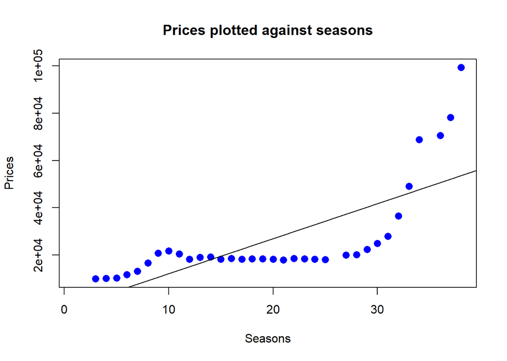

   ```r
   plot(seasons, district_k, pch = 16, cex = 1.3, col = "blue", main = "Prices plotted against seasons", xlab = "Seasons", ylab = "Prices")
   abline(regression_k)
   ```

2. Computing regression coefficients using all the data in the table :

   ```r
   prices=as.numeric(unlist(cleaned_data[,c(2:38)]))
   districts=c()
   seasons_total=c()
   for(i in 1:37){
     districts=c(districts,c(0:22)) # generating districts
     seasons_total=c(seasons_total,rep(38-i,23)) # generating seasons
   }
   regression_total=lm(prices~districts+seasons_total)
   summary(regression_total)
   ```

   ```
   ##
   ## Call:
   ## lm(formula = prices ~ districts + seasons_total)
   ##
   ## Residuals:
   ##    Min     1Q Median     3Q    Max
   ## -85331 -29176  -8260  16843 386544
   ##
   ## Coefficients:
   ##               Estimate Std. Error t value Pr(>|t|)
   ## (Intercept)    36960.7     4712.4   7.843 1.34e-14 ***
   ## districts      -4281.7      269.5 -15.885  < 2e-16 ***
   ## seasons_total   3745.5      168.6  22.214  < 2e-16 ***
   ## ---
   ## Signif. codes:  0 '***' 0.001 '**' 0.01 '*' 0.05 '.' 0.1 ' ' 1
   ##
   ## Residual standard error: 51790 on 835 degrees of freedom
   ##   (13 observations deleted due to missingness)
   ## Multiple R-squared:  0.4717, Adjusted R-squared:  0.4705
   ## F-statistic: 372.8 on 2 and 835 DF,  p-value: < 2.2e-16
   ```

3. Computing regression coefficients using indicator variables for districts :

   ```r
   district_names=c()
   for(i in 1:37){
     district_names=c(district_names,c("dis0","dis1","dis2" ,"dis3", "dis4", "dis5", "dis6", "dis7", "dis8", "dis9","dis10", "dis11", "dis12" ,"dis13" ,"dis14" ,"dis15" ,"dis16", "dis17", "dis18", 0, "dis20" ,"dis21", "dis22"))
   }
   regression_indicator=lm(prices~district_names+seasons_total)
   summary(regression_indicator)
   ```

   ```
   ##
   ## Call:
   ## lm(formula = prices ~ district_names + seasons_total)
   ##
   ## Residuals:
   ##    Min     1Q Median     3Q    Max
   ## -71029 -31612  -8130  20100 342218
   ##
   ## Coefficients:
   ##                     Estimate Std. Error t value Pr(>|t|)
   ## (Intercept)         -44392.4     8722.8  -5.089 4.47e-07 ***
   ## district_namesdis0   41053.7    11371.9   3.610 0.000325 ***
   ## district_namesdis1  104038.9    11371.9   9.149  < 2e-16 ***
   ## district_namesdis10  14931.7    11371.9   1.313 0.189542
   ## district_namesdis11  13823.6    11371.9   1.216 0.224493
   ## district_namesdis12   8553.2    11371.9   0.752 0.452191
   ## district_namesdis13  32705.3    11371.9   2.876 0.004133 **
   ## district_namesdis14  22611.3    11447.4   1.975 0.048578 *
   ## district_namesdis15   3627.3    11447.5   0.317 0.751429
   ## district_namesdis16   6877.3    11447.7   0.601 0.548166
   ## district_namesdis17  -2798.4    11527.6  -0.243 0.808253
   ## district_namesdis18  -2224.7    11371.9  -0.196 0.844946
   ## district_namesdis2   96079.7    11371.9   8.449  < 2e-16 ***
   ## district_namesdis20  -6846.2    11371.9  -0.602 0.547325
   ## district_namesdis21  10079.6    11526.8   0.874 0.382128
   ## district_namesdis22  21921.3    11371.9   1.928 0.054244 .
   ## district_namesdis3  112057.1    11371.9   9.854  < 2e-16 ***
   ## district_namesdis4   60008.0    11371.9   5.277 1.69e-07 ***
   ## district_namesdis5   47924.0    11371.9   4.214 2.79e-05 ***
   ## district_namesdis6   84036.1    11371.9   7.390 3.65e-13 ***
   ## district_namesdis7   53915.4    11371.9   4.741 2.51e-06 ***
   ## district_namesdis8   42741.4    11371.9   3.758 0.000183 ***
   ## district_namesdis9   10980.9    11610.6   0.946 0.344548
   ## seasons_total         3766.4      155.9  24.156  < 2e-16 ***
   ## ---
   ## Signif. codes:  0 '***' 0.001 '**' 0.01 '*' 0.05 '.' 0.1 ' ' 1
   ##
   ## Residual standard error: 47870 on 814 degrees of freedom
   ##   (13 observations deleted due to missingness)
   ## Multiple R-squared:   0.56,  Adjusted R-squared:  0.5476
   ## F-statistic: 45.05 on 23 and 814 DF,  p-value: < 2.2e-16
   ```

#### Which of part ii or iii is better?

4. Approach in part iii is better. In part ii, we assign each district a number ( for example 10 for district 10) which might be irrelevant to the price of that district, compared to other districts. Hence, this approach might result some errors. In the case of iii, we don’t have this problem. Also, in part iii, residual standard error is 47870, which is smaller that ii case ( which is 51790), so this is another reason showing that method iii is better.

### c

My student number is 98100504, which is congruent to 18 modulo 33, so we should take columns 15 and 16 in our current data frame:

```r
x=as.numeric(unlist(cleaned_data[c(1:23),c(16)]))
y=as.numeric(unlist(cleaned_data[c(1:23),c(15)]))
print("x :")
```

```
## [1] "x :"
```

```r
x
```

```
##  [1] 44736.43 80430.91 75995.10 89523.74 55667.92 49798.80 72695.78 57638.19
##  [9] 46151.79 26288.34 29347.10 28694.01 25090.43 42542.12 34396.13 22003.03
## [17] 25961.54 18485.50 17989.12 18372.15 14186.87 23506.86 34524.06
```

```r
print("y :")
```

```
## [1] "y :"
```

```r
y
```

```
##  [1] 44898.79 82204.45 77272.82 91153.73 55825.34 50050.02 73190.90 57815.77
##  [9] 46093.65 25906.42 29159.26 28325.24 24699.03 41598.12 33881.40 21903.94
## [17] 25204.45 18066.80 17725.08 18161.38 13981.31 23478.41 34228.94
```

1. We compute the mean and variance of x and y :

   ```r
   mean_x=mean(x)
   mean_y=mean(y)
   print(paste("mean of x:",mean_x))
   ```

   ```
   ## [1] "mean of x: 40609.8206971369"
   ```

   ```r
   print(paste("mean of y:",mean_y))
   ```

   ```
   ## [1] "mean of y: 40644.5754940135"
   ```

   ```r
   var_x=var(x)
   var_y=var(y)
   print(paste("variance of x:",var_x))
   ```

   ```
   ## [1] "variance of x: 488642930.76765"
   ```

   ```r
   print(paste("variance of y:",var_y))
   ```

   ```
   ## [1] "variance of y: 514526311.767709"
   ```

   Now, we compute t-value for these means and compute p-value from it :

   ```r
   n=length(x)
   sp=sqrt((var_x+var_y)/2)
   t=(mean_x-mean_y)/(sp*sqrt(2/n))
   p_value=2*pt(t,n-1,lower.tail = TRUE)
   print(paste("p value is: ",p_value))
   ```

   ```
   ## [1] "p value is:  0.995848585813387"
   ```

   Since p value is rather large ( much bigger than 0.05), so with the significance level of 0.05, we can’t reject null hypothesis.
2. We first compute z, its mean, variance and corresponding p value :

   ```r
   z=x-y
   mean_z=mean(z)
   var_z=var(z)
   print(paste("mean of z is :",mean_z))
   ```

   ```
   ## [1] "mean of z is : -34.754796876571"
   ```

   ```r
   print(paste("variance of z is :",var_z))
   ```

   ```
   ## [1] "variance of z is : 474110.348709174"
   ```

   ```r
   mean_z/sqrt(var_z/n)
   ```

   ```
   ## [1] -0.2420689
   ```

   ```r
   p_value_z=2*pt(mean_z/sqrt(var_z/n),n-1,lower.tail = TRUE)
   print(paste("p value for z is :",p_value_z))
   ```

   ```
   ## [1] "p value for z is : 0.810969052825411"
   ```

   p-value for z is also large, so again, we can’t reject null hypothesis with significance level 0.05.

#### Comparison between previous methods

The second method ( pairing samples ) is better. When pairing, we consider samples from one district with each other, and this prevents some errors that be because of the differences between samples in different districts. Also if we consider p-values computed in each method, p-value in first method is bigger than the p-value in the second method.